# Exam 3

## A. Maths

### Question 1.a

Yes. The OLS estimator has the smallest MSE only when a set of assumptions called the Gauss Markov assumptions are satisfied. The following are the gauss markov assumptions:

1. The true model is a linear function of the predictor variables
2. The conditional expectation of the residuals are zero
3. The variance of the residuals is constant
4. There is no serial correlation of the residuals.

If these conditions are not satisifed, there are other estimators that can provide a smaller MSE.

### Question 1.b

Suppose the outcome variable $y$ is a function of predictors $X$ such that,

$$ y = f(X)+\epsilon$$

where $\epsilon$ is the randomness in the model.

Since $f$ is not known, it is estimated from the training data to get a prediction of the form,

$$ \hat{y} = \hat{f}(X)$$

Therefore the MSE is defined as $E\big[(y-\hat{y})^2\big] = E\big[(f(X)-\hat{f}(X))^2\big] + Var(\epsilon) = \big(E[\hat{f}(X)]-f(X)\big)^2 + Var(\hat{f}(X)) + Var(\epsilon)$

Yes, the MSE measures the variance of the error in the model along with the bias and variance. By choosing a more flexible model, the MSE can always be reduced. But the reduction is due to the overfitting of the model to the randomness. Hence the irreducible error should act as a lower bound to the MSE. Since the true model is not known, the irreducible error cannot be estimated separately.

### Question 2

The RBF kernel is given by:

$$ k(x_i,x_j) = \exp\bigg(-\frac{||(x_i-x_j)||^2}{2\sigma^2}\bigg)$$

**(a)** is the right choice. As $||z_1-x|| \to 0 , \ k(z_1,x) \to \exp(0)$ which is equal to 1. As $||z_2-x|| \to \infty \ ,k(z_2,x) \to \exp(-\infty)$ which is zero.

### Question 3

Three types of loss functions used in decision trees:

1. Squared Loss - Regression
2. Gini Impurity - Classification
3. Entropy - Classification

**1. Squared Loss:**

The squared loss criteria chooses to split the node based on the category that minimizes the sum of the squared differences between the actual and predicted values. Mathematically, it is given by:

$$ Squared Loss = \sum_{i=1}^{n}(y_i-f(x_i))^2$$

.

At each node, the node is split based on the category of a feature that has the lowest total squared loss calculated from the observations that fall in that split.

**2. Gini Impurity:**

The Gini Impuirity measures how well the observations are classified with in a node. The gini impurity ranges from 0 to 0.5. A value of zero means that the observations are perfectly classified and the value of 0.5 means the observations has the same probability as a random chance. The Gini Impurity is expressed as:

$$ Gini \ Impurity = \sum_{i=1}^{n}p_i(1-p_i)$$

At each node the node split based on the category that has the lowest weighted gini impurity score.

**3. Entropy:**

The negative entropy measures how well the observations are classified similar to gini impurity. The range of entropy goes from 0 to 1. The impurities are penalized more in the negative entropy measure. The negative entropy is expressed as:

$$ Negative \ Entropy = -\sum_{i=1}^{n} p_i \log(p_i)$$

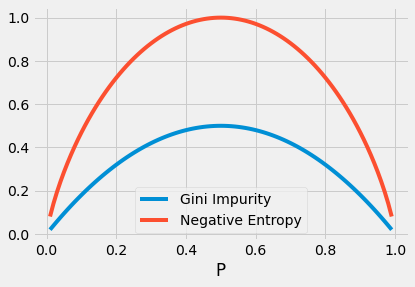

```python
import matplotlib.pyplot as plt
import numpy as np
p = np.linspace(0.01,0.99,99)
gini = (p*(1-p)+(1-p)*p)
entropy = -p*np.log2(p)-(1-p)*np.log2(1-p)
plt.plot(p,gini,label = "Gini Impurity")
plt.plot(p,entropy,label = "Negative Entropy")
plt.xlabel("P")
plt.legend()
```

The graph shows the values of gini and entropy for different values of probability.

## B. Models

### Question 4

#### Summary of the results

In this report following results were produced:

1. The ticker chosen for the report is Tata Motors (TTM-NASDAQ) and the period used is 2015-01-01 to 2022-10-01.
2. A preliminary model was initially created. The ROC AUC for the model was 0.5 on the test data. Hyper parameter tuning was done to improve the model.
3. Using grid search CV, the best model was selected from trying out different kernels, regualrization constant C, gamma and degree values. The polynomial kernel had the best ROC AUC score out of all the models in the CV. However it didnot provide a good classification of the test data. Hence it was concluded that the cross validation was not able to remove the overfitting in the model.
4. On investigating the PCA components for the features, it was found that the many of the components were not contributing to the total variance and it was decided to reduce the dimensionality.
5. After PCA, grid search CV was again used to find the best model from trying the same options as well as different number of principal components to be used.
6. The best model after doing PCA and SVC provided better results than the old model. Hence the model obtained after PCA and SVC is considered to be the best model in this report.
7. A trading strategy using the predictions obtained and backtested using the out of sample test data. It was then compared with the buy and hold strategy and was concluded that predictions obtained from the model are quite good. (Transaction costs and other liquidity aspects were not considered in the strategy, hence we cannot comment on the performance of the strategy but the quality of the predictions)

**Importing Libraries**

```python
import pandas as pd
import numpy as np
import matplotlib.pyplot as plt
import seaborn as sns
plt.style.use('fivethirtyeight')

# Preprocessing
from sklearn.preprocessing import StandardScaler,MinMaxScaler,RobustScaler
from sklearn.pipeline import Pipeline
from sklearn.model_selection import train_test_split, TimeSeriesSplit, GridSearchCV

# SVM
from sklearn.svm import SVC

# Metrics
from sklearn.metrics import accuracy_score, classification_report, confusion_matrix
from sklearn.metrics import plot_confusion_matrix, auc, roc_curve, plot_roc_curve

# Ignore warnings
import warnings
warnings.filterwarnings('ignore')

#Yahoo Finance
import yfinance as yf

from tabulate import tabulate

pd.options.display.max_columns = 100
```

#### Data Extraction

The ticker chosen for this report is Tata Motors. The data range is taken from 2015 till 2022 Oct.

```python
df_backup = yf.download("TTM",start = "2015-01-01",end="2022-10-01",progress=False)
```

```python
df = df_backup.copy()
```

```python
len(df) # number of obs
```

```
1952
```

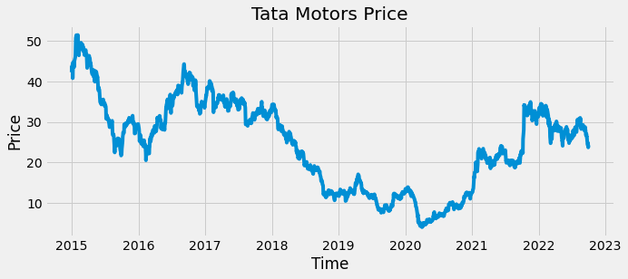

```python
plt.figure(figsize=(10,4))
plt.plot(df["Adj Close"])
plt.title("Tata Motors Price")
plt.xlabel("Time")
plt.ylabel("Price")
```

#### Feature Creation

The following features are created:

1. Open minus Close
2. High minus Low
3. Previous day returns $r_{t-1},\ r_{t-2}...r_{t-10}$
4. Sign of the current return $r_t$
5. Change in adjusted closing price over the last 5 days
6. Simple Moving averages - $SMA_{10},SMA_{20}, SMA_{50}$
7. Exponential moving average
8. Previous Day Volume, $V_{t-1}$

```python
# Open minus Close
df["O-C"] = df["Open"]-df["Close"]

# High minus Low
df["H-L"] = df["High"]-df["Low"]

# Calculating Returns and Sign
df["Returns"] = np.log(df["Adj Close"]).diff()
df["Sign"] = np.where(df["Returns"]>0,1,0)

# Previous day returns
for i in range(1,11):
    df["r_"+str(i)] = df["Returns"].shift(i)

# Price change over the last 10 days
df["Momentum"] = df["Adj Close"].diff(5)

# SMA 10, SMA 20, SMA 50
for i in [10,20,50]:
    df["SMA_"+str(i)] = df["Adj Close"].rolling(i).mean()

# Function for EMA
def EMA(n):
    alpha = 2/(n+1)
    EMA = [df["Adj Close"].iloc[0]]
    for i in range(1,len(df)):
        EMA.append(alpha*df["Adj Close"].iloc[i]+(1-alpha)*EMA[-1])
    return EMA

# EMA 10,EMA 20, EMA 50
for i in [10,20,50]:
    df["EMA_"+str(i)] = EMA(i)

# Previous Day Volume
df["V_1"] = df["Volume"].shift(1)
```

```python
# Dropping all NAs
df = df.dropna()
```

```python
len(df)
```

```
1903
```

```python
df.columns
```

```
Index(['Open', 'High', 'Low', 'Close', 'Adj Close', 'Volume', 'O-C', 'H-L',
       'Returns', 'Sign', 'r_1', 'r_2', 'r_3', 'r_4', 'r_5', 'r_6', 'r_7',
       'r_8', 'r_9', 'r_10', 'Momentum', 'SMA_10', 'SMA_20', 'SMA_50',
       'EMA_10', 'EMA_20', 'EMA_50', 'V_1'],
      dtype='object')
```

```python
X = df.drop(["Open","High","Low","Close","Adj Close",'Volume',"Returns"],axis=1).values
```

```python
X.shape
```

```
(1903, 21)
```

#### Defining Target

In this report the target variable is the trend of the one day forward returns $r_{t+1}$. If the forward returns are positive they are labelled as 1 and if they are negative they are labelled as zero.

```python
df["Forward Returns"] = np.log(df["Adj Close"]).diff().shift(-1)
df = df.iloc[:-1,]
```

Small near-zero returns are grouped together with negative in the Class zero. Returns less than 0.25% are categorized as near zero returns.

```python
e = 0.25/100
y = np.where(df["Forward Returns"]>e,1,0)
```

```python
pd.Series(y).value_counts()/len(df)
```

```
0    0.553628
1    0.446372
dtype: float64
```

We see that there 55% observations are under class 0 and 45% are under class 1. There is no huge imbalance of one particular class in the data.

**Timeseries Split**

```python
# Removing Last row
X = X[:-1]
```

The train test split function is used to split the data. Shuffle is set to false to remove forward looking bias.

```python
X_train,X_test,y_train,y_test = train_test_split(X,y,test_size=0.2,shuffle=False)
```

```python
X_train.shape
```

```
(1521, 21)
```

```python
y_train.shape
```

```
(1521,)
```

**Support Vector Machines for Classification**

The support vector machine for binary classification is an optimization problem which is mathematically given below:

$$min\ \frac{1}{2}||\textbf{w}||^2 + C\sum_{i=1}^{n}\zeta_i$$

subject to the constraints $$\begin{align} y_i(\textbf{w}^T\textbf{x}_i+b) &\ge 1-\zeta_i\\ \zeta_i &\ge 0 \end{align}$$

The support vector classifier fits a hyperplane that separates the classes while minimizing the degree of misclassifications. To get non linear decision boundaries, the kernel trick is used to project the feature vectors into higher dimensional space.

#### Preliminary model

```python
pipe = Pipeline([("scaler",StandardScaler()),("Classifier",SVC(max_iter=100000))])
```

```python
pipe.fit(X_train,y_train)
```

```
Pipeline(steps=[('scaler', StandardScaler()),
                ('Classifier', SVC(max_iter=100000))])
```

The model is fitted to the training data. Now the train accuracy and the test accuracy are calculated.

```python
y_train_pred = pipe.predict(X_train)
y_test_pred = pipe.predict(X_test)
```

```python
print("Classification report for Training Data")
print("---------------------------------------")
print(classification_report(y_train,y_train_pred))
```

```
Classification report for Training Data
---------------------------------------
              precision    recall  f1-score   support

           0       0.65      0.96      0.78       860
           1       0.87      0.34      0.49       661

    accuracy                           0.69      1521
   macro avg       0.76      0.65      0.63      1521
weighted avg       0.75      0.69      0.65      1521
```

```python
print("Classification report for Test Data")
print("---------------------------------------")
print(classification_report(y_test,y_test_pred))
```

```
Classification report for Test Data
---------------------------------------
              precision    recall  f1-score   support

           0       0.50      0.87      0.64       193
           1       0.47      0.12      0.19       188

    accuracy                           0.50       381
   macro avg       0.49      0.49      0.41       381
weighted avg       0.49      0.50      0.42       381
```

The train accuracy is around 69% and the test accuracy is around 50% and if we take the precision for class 1 as the metric it is around 47% for the test.

Looking at the recall values as well, we see that most of the values are classified as class 0. However this is only a preliminary model. This is more evidently captured in the confusion matrix.

```
<sklearn.metrics._plot.confusion_matrix.ConfusionMatrixDisplay at 0x1f070bccb20>
```

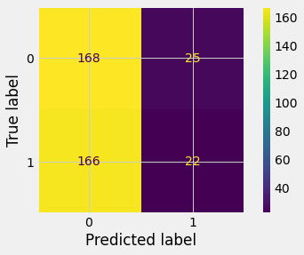

```python
plot_confusion_matrix(pipe,X_test,y_test)
```

The roc curve is investigated next. The area under the roc curve gives the score of the classifier and how it is sensitive to different thresholds. A score of 0.5 is same as a random assignment of values.

```
<sklearn.metrics._plot.roc_curve.RocCurveDisplay at 0x1f070c101f0>
```

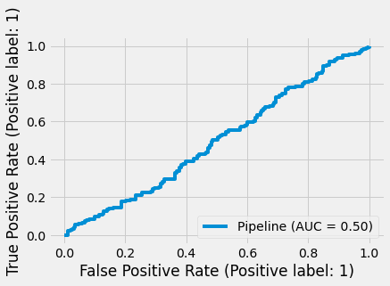

```python
plot_roc_curve(pipe,X_test,y_test)
```

The area under the curve is around 0.5 which means the model is not better than randomly guessing the class.

#### Hyper parameter Tuning

The list of parameters is first investigated.

```python
pipe.get_params()
```

```
{'memory': None,
 'steps': [('scaler', StandardScaler()), ('Classifier', SVC(max_iter=100000))],
 'verbose': False,
 'scaler': StandardScaler(),
 'Classifier': SVC(max_iter=100000),
 'scaler__copy': True,
 'scaler__with_mean': True,
 'scaler__with_std': True,
 'Classifier__C': 1.0,
 'Classifier__break_ties': False,
 'Classifier__cache_size': 200,
 'Classifier__class_weight': None,
 'Classifier__coef0': 0.0,
 'Classifier__decision_function_shape': 'ovr',
 'Classifier__degree': 3,
 'Classifier__gamma': 'scale',
 'Classifier__kernel': 'rbf',
 'Classifier__max_iter': 100000,
 'Classifier__probability': False,
 'Classifier__random_state': None,
 'Classifier__shrinking': True,
 'Classifier__tol': 0.001,
 'Classifier__verbose': False}
```

The hyperparameters chosen for further tuning are:

1. scaler - Standard scaler, Minmax scaler, Robust scaler
2. Classifier__kernel - linear, poly, rbf, sigmoid.
3. Classifier__C - Regularization parameter
4. Classifier__degree - applicable only for polynomial kernel
5. Classifier__gamma - applicable for rbf, sigmoid and poly

Since different options are valid only for few of the kernel functions, the hyper parameter tuning is done separately for each kernel and the best parameters for the kernel are estimated. Finally the best model out of the final candidate models is selected. The metric used for hyperparameter tuning is the roc auc.

**Splitting the data for Time series Cross validation**

To estimate the best parameters using cross validation, the training data is split using time series split which uses the forward chaining method to split the data. Only the training data is used to estimate the best model since we dont want to have information of the test data to estimate the parameters.

```python
tscv = TimeSeriesSplit(n_splits=5,gap=1)
```

Parameter grids for each of the kernel functions are created

```python
linear_params_grid = {"scaler":[StandardScaler(),MinMaxScaler(),RobustScaler()],
                      "Classifier__C": [0.1,1,10,100,1000],
                      "Classifier__kernel":["linear"]
                     }

poly_params_grid = {"scaler":[StandardScaler(),MinMaxScaler(),RobustScaler()],
                      "Classifier__C": [0.1,1,10,100,1000],
                      "Classifier__kernel":["poly"],
                    "Classifier__degree":[1,2,3,4,5],
                    "Classifier__gamma":["scale",0.1,1,10,100,1000]
                   }

rbf_params_grid = {"scaler":[StandardScaler(),MinMaxScaler(),RobustScaler()],
                      "Classifier__C": [0.1,1,10,100,1000],
                      "Classifier__kernel":["rbf"],
                    "Classifier__gamma":["scale",0.1,1,10,100,1000]}


sigmoid_params_grid = {"scaler":[StandardScaler(),MinMaxScaler(),RobustScaler()],
                      "Classifier__C": [0.1,1,10,100,1000],
                      "Classifier__kernel":["sigmoid"],
                    "Classifier__gamma":["scale",0.1,1,10,100,1000]
                   }
```

```python
cv_results = []
params_grid_list = [linear_params_grid,poly_params_grid,rbf_params_grid,sigmoid_params_grid]
for param_grid in params_grid_list:
    cv = GridSearchCV(pipe,param_grid,scoring="roc_auc",cv=tscv)
    cv.fit(X_train,y_train)
    cv_results.append(cv)
```

```python
best_scores = [cv.best_score_ for cv in cv_results]
```

```python
print(tabulate(np.array([["Linear","Poly","RBF","Sigmoid"],np.round(best_scores,4)]).T,
              headers=["Kernel","best score"]))
```

```
Kernel      best score
--------  ------------
Linear          0.5361
Poly            0.5427
RBF             0.5413
Sigmoid         0.5282
```

```python
best_estimators = [cv.best_estimator_ for cv in cv_results]
print(tabulate(np.array([["Linear","Poly","RBF","Sigmoid"],best_estimators]).T,
              headers=["Kernel","best estimator"]))
```

```
Kernel    best estimator
--------  -----------------------------------------------------------------------------
Linear    Pipeline(steps=[('scaler', StandardScaler()),
                          ('Classifier', SVC(C=10, kernel='linear', max_iter=100000))])
Poly      Pipeline(steps=[('scaler', MinMaxScaler()),
                          ('Classifier',
                           SVC(C=100, degree=5, gamma=0.1, kernel='poly',
                               max_iter=100000))])
RBF       Pipeline(steps=[('scaler', RobustScaler()),
                          ('Classifier', SVC(C=1, max_iter=100000))])
Sigmoid   Pipeline(steps=[('scaler', MinMaxScaler()),
                          ('Classifier',
                           SVC(C=0.1, gamma=1, kernel='sigmoid', max_iter=100000))])
```

#### Using the best estimator to predict the trend in the test data

```python
best_model = cv_results[np.array(best_scores).argmax()].best_estimator_
best_model
```

```
Pipeline(steps=[('scaler', MinMaxScaler()),
                ('Classifier',
                 SVC(C=100, degree=5, gamma=0.1, kernel='poly',
                     max_iter=100000))])
```

```python
y_test_pred = best_model.predict(X_test)
```

```
<sklearn.metrics._plot.confusion_matrix.ConfusionMatrixDisplay at 0x1f074d99550>
```

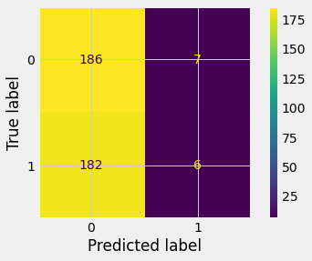

```python
plot_confusion_matrix(best_model,X_test,y_test)
```

```python
print(classification_report(y_test,y_test_pred))
```

```
              precision    recall  f1-score   support

           0       0.51      0.96      0.66       193
           1       0.46      0.03      0.06       188

    accuracy                           0.50       381
   macro avg       0.48      0.50      0.36       381
weighted avg       0.48      0.50      0.37       381
```

```
<sklearn.metrics._plot.roc_curve.RocCurveDisplay at 0x1f074e5a790>
```

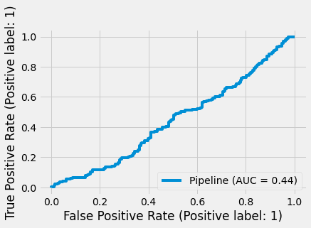

```python
plot_roc_curve(best_model,X_test,y_test)
```

The Area under the ROC is only 0.44 which is significantly lower than the preliminary model. This shows that cross validation does not do a job of removing the overfitting and the best model clearly overfits the data.

#### Investigating the feature matrix

The correlation matrix of the feature vectors are investigated here.

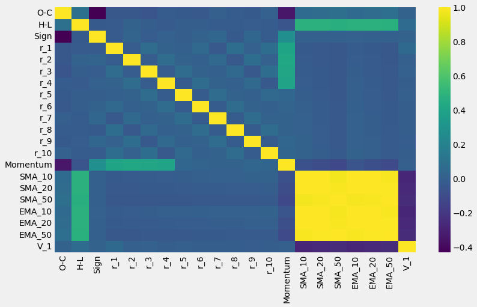

```python
feature_names = df.drop(["Open","High","Low","Close","Adj Close",'Volume',"Forward Returns","Returns"],axis=1).columns
plt.figure(figsize=(12,7))
sns.heatmap(pd.DataFrame(np.corrcoef(X,rowvar=False),index=feature_names,columns=feature_names),cmap="viridis")
```

There seems to be perfect correlation in the moving average features which is expected since they measure the same thing. Reducing the dimensionality using PCA may give better results.

#### Using Principal Component Analysis to reduce the dimensionality

```python
from sklearn.decomposition import PCA
```

```python
X_PCA= StandardScaler().fit_transform(X)
```

```python
np.mean(X_PCA,axis=0)
```

```
array([-7.47153245e-18, -4.48291947e-17, -9.71299218e-17, -3.73576622e-18,
        3.73576622e-18,  3.73576622e-18,  3.73576622e-18,  7.47153245e-18,
        1.12072987e-17, -1.12072987e-17, -3.73576622e-18,  1.86788311e-17,
        1.86788311e-17,  0.00000000e+00, -1.79316779e-16, -1.19544519e-16,
        2.39089038e-16,  1.19544519e-16,  0.00000000e+00,  1.19544519e-16,
        2.98861298e-17])
```

```python
PCA_model = PCA().fit(X_PCA)
```

```python
exp_var = pd.DataFrame(PCA_model.explained_variance_ratio_,columns=["Explained Variance %"],index=range(1,22))
exp_var["Cumulative"] = np.cumsum(exp_var["Explained Variance %"])
```

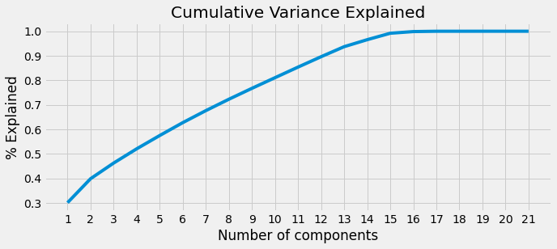

```python
plt.figure(figsize=(10,4))
plt.plot(exp_var["Cumulative"])
plt.title("Cumulative Variance Explained")
plt.xlabel("Number of components")
plt.ylabel("% Explained")
plt.xticks(range(1,22))
plt.show()
```

We see that 4 components explain more than 50% of the variation, 8 components explain more than 70% of the variation and 12 components explains 90% of the variation. It is not required to include more than 14 components. The number of components to include can be a hyperparameter to be selected using cross validation. The range for this number of components can be between 4 to 12.

```python
pipe_PCA = Pipeline([("scaler",StandardScaler()),("pca",PCA(random_state=42)),('Classifier',SVC(max_iter=100000))])
```

#### Finding the best params using timeseries cross validation after PCA

```python
pipe_PCA.get_params()
```

```
{'memory': None,
 'steps': [('scaler', StandardScaler()),
  ('pca', PCA(random_state=42)),
  ('Classifier', SVC(max_iter=100000))],
 'verbose': False,
 'scaler': StandardScaler(),
 'pca': PCA(random_state=42),
 'Classifier': SVC(max_iter=100000),
 'scaler__copy': True,
 'scaler__with_mean': True,
 'scaler__with_std': True,
 'pca__copy': True,
 'pca__iterated_power': 'auto',
 'pca__n_components': None,
 'pca__random_state': 42,
 'pca__svd_solver': 'auto',
 'pca__tol': 0.0,
 'pca__whiten': False,
 'Classifier__C': 1.0,
 'Classifier__break_ties': False,
 'Classifier__cache_size': 200,
 'Classifier__class_weight': None,
 'Classifier__coef0': 0.0,
 'Classifier__decision_function_shape': 'ovr',
 'Classifier__degree': 3,
 'Classifier__gamma': 'scale',
 'Classifier__kernel': 'rbf',
 'Classifier__max_iter': 100000,
 'Classifier__probability': False,
 'Classifier__random_state': None,
 'Classifier__shrinking': True,
 'Classifier__tol': 0.001,
 'Classifier__verbose': False}
```

The hyperparameters selected for the scaler and the support vector classifier are kept the same. We add one more hyper parameter which is the pca__n_components.

```python
cv_pca_results = []
params_grid_list = [linear_params_grid,poly_params_grid,rbf_params_grid,sigmoid_params_grid]
for param_grid in params_grid_list:
    param_grid['pca__n_components'] = [4,8,12]
    cv = GridSearchCV(pipe_PCA,param_grid,scoring="roc_auc",cv=tscv)
    cv.fit(X_train,y_train)
    cv_pca_results.append(cv)
```

```python
best_scores_pca = [cv.best_score_ for cv in cv_pca_results]
print(tabulate(np.array([["Linear","Poly","RBF","Sigmoid"],np.round(best_scores_pca,4)]).T,
              headers=["Kernel","best score"]))
```

```
Kernel      best score
--------  ------------
Linear          0.5486
Poly            0.5486
RBF             0.5547
Sigmoid         0.536
```

```python
best_model_pca = cv_pca_results[np.array(best_scores_pca).argmax()].best_estimator_
best_model_pca
```

```
Pipeline(steps=[('scaler', RobustScaler()),
                ('pca', PCA(n_components=8, random_state=42)),
                ('Classifier', SVC(C=100, max_iter=100000))])
```

The best model is based on the rbf kernel with 8 components which is different from the model without PCA.

```python
y_test_pred = best_model_pca.predict(X_test)
```

```
<sklearn.metrics._plot.confusion_matrix.ConfusionMatrixDisplay at 0x1f071a1cd30>
```

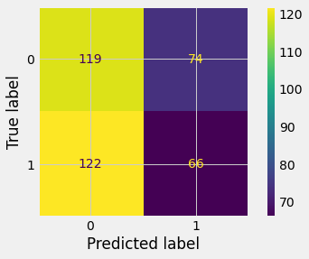

```python
plot_confusion_matrix(best_model_pca,X_test,y_test)
```

```python
print(classification_report(y_test,y_test_pred))
```

```
              precision    recall  f1-score   support

           0       0.49      0.62      0.55       193
           1       0.47      0.35      0.40       188

    accuracy                           0.49       381
   macro avg       0.48      0.48      0.48       381
weighted avg       0.48      0.49      0.48       381
```

```
<sklearn.metrics._plot.roc_curve.RocCurveDisplay at 0x1f070eacf10>
```

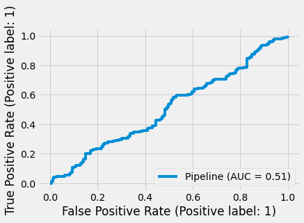

```python
plot_roc_curve(best_model_pca,X_test,y_test)
```

The area under the ROC is 0.51 which is slightly higher than random assignment. But it is significantly better than the model without PCA.

Using the best model obtained after PCA and SVC, we backtest the predictions on the test data and check the performance.

#### Trading Strategy

We create a trading strategy by staying invested when the prediction is 1 and investing in cash when prediction is 0. Here for simplicity, returns on cash are considered zero and no trading costs, brokerage and bid ask spread are considered.

```python
#df.index = df.index.tz_localize('utc')
strategy = df["Forward Returns"].iloc[-len(y_test_pred):,]*y_test_pred
```

```python
strategy
```

```
Date
2021-03-29 00:00:00+00:00    0.000000
2021-03-30 00:00:00+00:00    0.013072
2021-03-31 00:00:00+00:00    0.011478
2021-04-01 00:00:00+00:00   -0.004766
2021-04-05 00:00:00+00:00   -0.000000
                               ...
2022-09-23 00:00:00+00:00   -0.000000
2022-09-26 00:00:00+00:00    0.003700
2022-09-27 00:00:00+00:00    0.017894
2022-09-28 00:00:00+00:00   -0.000000
2022-09-29 00:00:00+00:00    0.000000
Name: Forward Returns, Length: 381, dtype: float64
```

```python
strategy_df = pd.DataFrame(strategy,index=(df["Forward Returns"].iloc[-len(y_test_pred):,].index))
strategy_df.columns = ["Strategy"]
```

```python
# Import pyfolio
import pyfolio as pf
```

| Start date End date Total months | 2021-03-29 2022-09-29 18 Backtest | 2021-03-29 2022-09-29 18 |
| --- | --- | --- |
| Annual return | 22.287% |  |
| Cumulative returns | 35.554% |  |
| Annual volatility | 29.015% |  |
| Sharpe ratio | 0.84 |  |
| Calmar ratio | 0.83 |  |
| Stability | 0.50 |  |
| Max drawdown | -26.792% |  |
| Omega ratio | 1.27 |  |
| Sortino ratio | 1.37 |  |
| Skew | 1.14 |  |
| Kurtosis | 10.19 |  |
| Tail ratio | 1.25 |  |
| Daily value at risk | -3.559% |  |
| Alpha | 0.22 |  |
| Beta | 0.41 |  |

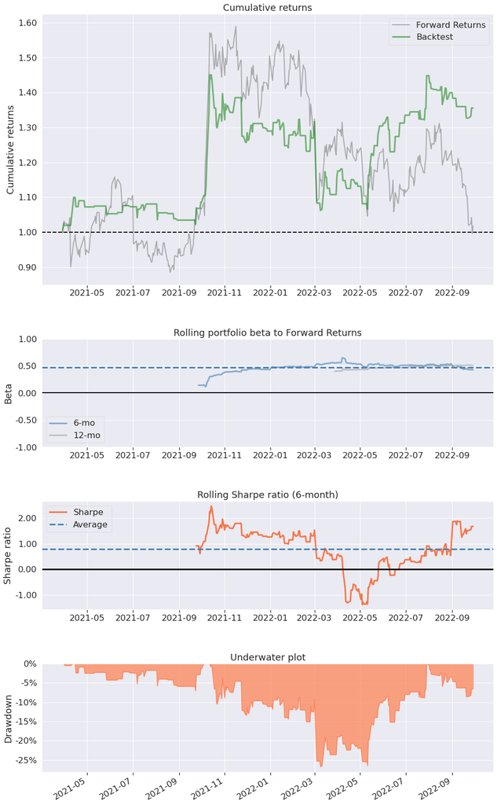

```python
# Create Tear sheet using pyfolio for outsample - for X_test
pf.create_simple_tear_sheet(strategy_df['Strategy'],benchmark_rets=df["Forward Returns"].iloc[-len(y_test_pred):,])
```

The annual returns from the strategy during the period of 18 months is 22.28% vs. only 1.18% for a buy and hold strategy. The annual volatility, max draw down and the daily VaR are all smaller than the buy and hold strategy. Hence we conclude that predictions obtained by the model are quite good. If we used the best model without PCA, due to low recall for class 1, we will not be able to predict the trends correctly.